# Data Science and Business Analytics

#### XGBoost Model

```python
xgbc_estimator = XGBClassifier(
    random_state=1, eval_metric="logloss", enable_categorical=True
)
xgbc_estimator.fit(X_train, y_train)
```

```
XGBClassifier(base_score=None, booster=None, callbacks=None,
              colsample_bylevel=None, colsample_bynode=None,
              colsample_bytree=None, device=None, early_stopping_rounds=None,
              enable_categorical=True, eval_metric='logloss',
              feature_types=None, gamma=None, grow_policy=None,
              importance_type=None, interaction_constraints=None,
              learning_rate=None, max_bin=None, max_cat_threshold=None,
              max_cat_to_onehot=None, max_delta_step=None, max_depth=None,
              max_leaves=None, min_child_weight=None, missing=nan,
              monotone_constraints=None, multi_strategy=None, n_estimators=None,
              n_jobs=None, num_parallel_tree=None, random_state=1, ...)
```

##### Evaluate XGBoost Model on the Training data

```
Training Performance:
```

|  | Accuracy | Recall | Precision | F1 |
| --- | --- | --- | --- | --- |
| 0 | 0.843 | 0.931 | 0.849 | 0.888 |

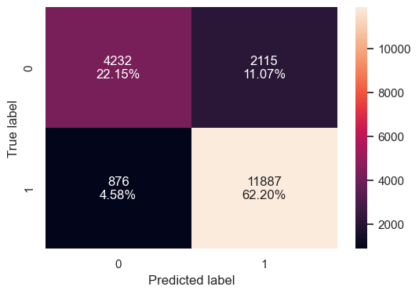

```python
# Evaluate the model on the training data
print("Training Performance:")
xgbc_train_perf = model_performance_classification_sklearn(
    xgbc_estimator, X_train, y_train
)
display(xgbc_train_perf)

# Plot the confusion matrix for the training set
confusion_matrix_sklearn(xgbc_estimator, X_train, y_train)
```

##### Evaluate XGBoost Model on the Test data

```
Test Performance:
```

|  | Accuracy | Recall | Precision | F1 |
| --- | --- | --- | --- | --- |
| 0 | 0.730 | 0.859 | 0.765 | 0.809 |

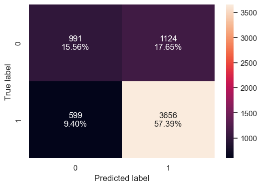

```python
# Evaluate the model on the test data
print("Test Performance:")
xgbc_test_perf = model_performance_classification_sklearn(
    xgbc_estimator, X_test, y_test
)
display(xgbc_test_perf)

# Plot the confusion matrix for the test set
confusion_matrix_sklearn(xgbc_estimator, X_test, y_test)
```

**Observations:**

#### XGBoost Hyperparameter Tuning Model

> **Note**
> 1. Sample parameter grids have been provided to do necessary hyperparameter tuning. These sample grids are expected to provide a balance between model performance improvement and execution time. One can extend/reduce the parameter grid based on execution time and system configuration.
> - Please note that if the parameter grid is extended to improve the model performance further, the execution time will increase
> - For XGBoost:

```
param_grid={'n_estimators':np.arange(50,110,25),
            'scale_pos_weight':[1,2,5],
            'learning_rate':[0.01,0.1,0.05],
            'gamma':[1,3],
            'subsample':[0.7,0.9]
}
```

```python
# Choose the type of classifier.
xgbc_tuned = XGBClassifier(
    random_state=1, eval_metric="logloss", enable_categorical=True
)

# Grid of parameters to choose from
## add from
parameters = {
    "n_estimators": np.arange(50, 110, 25),
    "scale_pos_weight": [1, 2, 5],
    "learning_rate": [0.01, 0.1, 0.05],
    "gamma": [1, 3],
    "subsample": [0.7, 0.9],
}

# Type of scoring used to compare parameter combinations
acc_scorer = metrics.make_scorer(metrics.f1_score)

# Run the grid search
grid_obj = GridSearchCV(xgbc_tuned, parameters, scoring=acc_scorer, cv=5)
grid_obj = grid_obj.fit(X_train, y_train)

# Set the clf to the best combination of parameters
xgbc_tuned = grid_obj.best_estimator_

# Fit the best algorithm to the data.
xgbc_tuned.fit(X_train, y_train)
```

```
XGBClassifier(base_score=None, booster=None, callbacks=None,
              colsample_bylevel=None, colsample_bynode=None,
              colsample_bytree=None, device=None, early_stopping_rounds=None,
              enable_categorical=True, eval_metric='logloss',
              feature_types=None, gamma=1, grow_policy=None,
              importance_type=None, interaction_constraints=None,
              learning_rate=0.05, max_bin=None, max_cat_threshold=None,
              max_cat_to_onehot=None, max_delta_step=None, max_depth=None,
              max_leaves=None, min_child_weight=None, missing=nan,
              monotone_constraints=None, multi_strategy=None, n_estimators=50,
              n_jobs=None, num_parallel_tree=None, random_state=1, ...)
```

##### Evaluate XGBoost Hyperparameter Tuning Model on the Training data

```
Training Performance:
```

|  | Accuracy | Recall | Precision | F1 |
| --- | --- | --- | --- | --- |
| 0 | 0.765 | 0.889 | 0.787 | 0.835 |

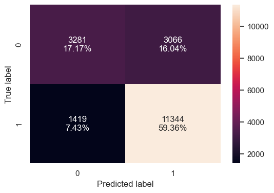

```python
# Evaluate the model on the Training data
print("Training Performance:")
xgbct_train_perf = model_performance_classification_sklearn(
    xgbc_tuned, X_train, y_train
)
display(xgbct_train_perf)

# Plot the confusion matrix for the Training set
confusion_matrix_sklearn(xgbc_tuned, X_train, y_train)
```

##### Evaluate XGBoost Hyperparameter Tuning Model on the Test data

```
Test Performance:
```

|  | Accuracy | Recall | Precision | F1 |
| --- | --- | --- | --- | --- |
| 0 | 0.743 | 0.877 | 0.770 | 0.820 |

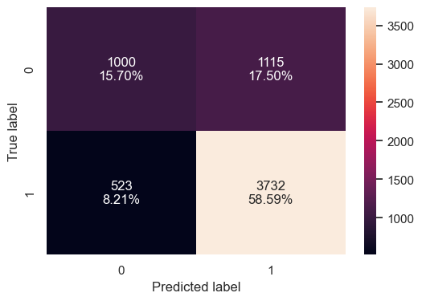

```python
# Evaluate the model on the test data
print("Test Performance:")
xgbct_test_perf = model_performance_classification_sklearn(xgbc_tuned, X_test, y_test)
display(xgbct_test_perf)

# Plot the confusion matrix for the test set
confusion_matrix_sklearn(xgbc_tuned, X_test, y_test)
```

**Observations:**

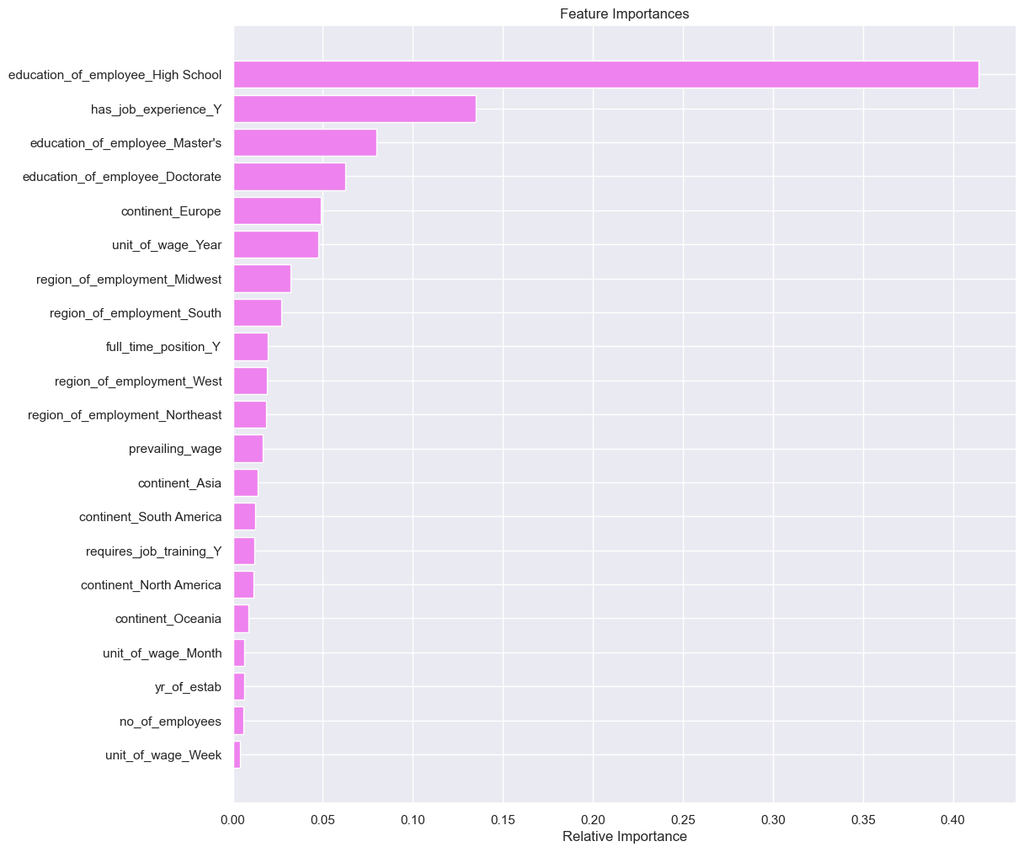

```python
importances = xgbc_tuned.feature_importances_
indices = np.argsort(importances)
feature_names = list(X.columns)

plt.figure(figsize=(12, 12))
plt.title("Feature Importances")
plt.barh(range(len(indices)), importances[indices], color="violet", align="center")
plt.yticks(range(len(indices)), [feature_names[i] for i in indices])
plt.xlabel("Relative Importance")
plt.show()
```

- Here we can also see the feature importance of the Tuned XGBoost model is comparable to the previous boosting models.
- Where some of the most important features was again if the applicant went to highschool, has had previous job experience, and/or if they have a Masters or a PhD.

### Model Performance Comparison AdaBoost, Gradient Boosting, and XGBoost

```python
# Define the list of models
models = [
    abc_estimator,
    abc_tuned,
    gbc_estimator,
    gbc_tuned,
    xgbc_estimator,
    xgbc_tuned,
]

# Define empty lists to add train and test results
acc_train = []
acc_test = []
recall_train = []
recall_test = []
precision_train = []
precision_test = []
f1_train = []
f1_test = []

# Loop through all the models to get the accuracy, recall, precision, and F1 scores
for model in models:
    # Get metrics for training data
    train_perf = model_performance_classification_sklearn(model, X_train, y_train)
    # Get metrics for test data
    test_perf = model_performance_classification_sklearn(model, X_test, y_test)

    # Append the metrics to respective lists with adjusted rounding
    acc_train.append(np.round(train_perf["Accuracy"][0], 4))
    acc_test.append(np.round(test_perf["Accuracy"][0], 4))
    recall_train.append(np.round(train_perf["Recall"][0], 4))
    recall_test.append(np.round(test_perf["Recall"][0], 4))
    precision_train.append(np.round(train_perf["Precision"][0], 4))
    precision_test.append(np.round(test_perf["Precision"][0], 4))
    f1_train.append(np.round(train_perf["F1"][0], 4))
    f1_test.append(np.round(test_perf["F1"][0], 4))
```

```python
# Creating a DataFrame to compare model performance
comparison_frame = pd.DataFrame(
    {
        "Model": [
            "AdaBoost with Default Parameters",
            "AdaBoost Tuned",
            "Gradient Boosting with Default Parameters",
            "Gradient Boosting Tuned",
            "XGBoost with Default Parameters",
            "XGBoost Tuned",
        ],
        "Train_Accuracy": acc_train,
        "Test_Accuracy": acc_test,
        "Train_Recall": recall_train,
        "Test_Recall": recall_test,
        "Train_Precision": precision_train,
        "Test_Precision": precision_test,
        "Train_F1_Score": f1_train,
        "Test_F1_Score": f1_test,
    }
)

# Displaying the comparison DataFrame
display(comparison_frame)
```

|  | Model | Train_Accuracy | Test_Accuracy | Train_Recall | Test_Recall | Train_Precision | Test_Precision | Train_F1_Score | Test_F1_Score |
| --- | --- | --- | --- | --- | --- | --- | --- | --- | --- |
| 0 | AdaBoost with Default Parameters | 0.739 | 0.728 | 0.889 | 0.884 | 0.761 | 0.752 | 0.820 | 0.812 |
| 1 | AdaBoost Tuned | 0.754 | 0.739 | 0.887 | 0.882 | 0.776 | 0.764 | 0.828 | 0.819 |
| 2 | Gradient Boosting with Default Parameters | 0.759 | 0.741 | 0.881 | 0.873 | 0.785 | 0.769 | 0.830 | 0.818 |
| 3 | Gradient Boosting Tuned | 0.756 | 0.741 | 0.885 | 0.880 | 0.779 | 0.767 | 0.829 | 0.820 |
| 4 | XGBoost with Default Parameters | 0.844 | 0.730 | 0.931 | 0.859 | 0.849 | 0.765 | 0.888 | 0.809 |
| 5 | XGBoost Tuned | 0.765 | 0.743 | 0.889 | 0.877 | 0.787 | 0.770 | 0.835 | 0.820 |

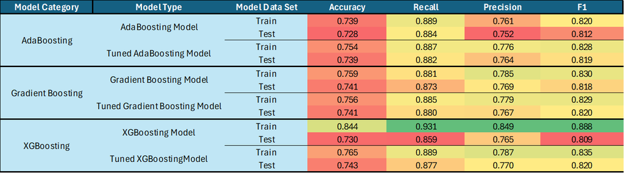

## Model Performance Comparison and Conclusions

```python
# Define the list of all models
models = [
    dtc_estimator,
    dtc_tuned,
    bc_estimator,
    bc_tuned,
    rfc_estimator,
    rfc_tuned,
    abc_estimator,
    abc_tuned,
    gbc_estimator,
    gbc_tuned,
    xgbc_estimator,
    xgbc_tuned,
]

# Define empty lists to add train and test results
acc_train = []
acc_test = []
recall_train = []
recall_test = []
precision_train = []
precision_test = []
f1_train = []
f1_test = []

# Loop through all the models to get the accuracy, recall, precision, and F1 scores
for model in models:
    # Get metrics for training data
    train_perf = model_performance_classification_sklearn(model, X_train, y_train)
    # Get metrics for test data
    test_perf = model_performance_classification_sklearn(model, X_test, y_test)

    # Append the metrics to respective lists with adjusted rounding
    acc_train.append(np.round(train_perf["Accuracy"][0], 4))
    acc_test.append(np.round(test_perf["Accuracy"][0], 4))
    recall_train.append(np.round(train_perf["Recall"][0], 4))
    recall_test.append(np.round(test_perf["Recall"][0], 4))
    precision_train.append(np.round(train_perf["Precision"][0], 4))
    precision_test.append(np.round(test_perf["Precision"][0], 4))
    f1_train.append(np.round(train_perf["F1"][0], 4))
    f1_test.append(np.round(test_perf["F1"][0], 4))
```

```python
# Creating a DataFrame to compare model performance
comparison_frame = pd.DataFrame(
    {
        "Model": [
            "Decision Tree Model",
            "Tuned Decision Tree Model",
            "Bagging Classifier Model",
            "Tuned Bagging Classifier Model",
            "Random Forest Model",
            "Tuned Random Forest Model",
            "AdaBoost with Default Parameters",
            "AdaBoost Tuned",
            "Gradient Boosting with Default Parameters",
            "Gradient Boosting Tuned",
            "XGBoost with Default Parameters",
            "XGBoost Tuned",
        ],
        "Train_Accuracy": acc_train,
        "Test_Accuracy": acc_test,
        "Train_Recall": recall_train,
        "Test_Recall": recall_test,
        "Train_Precision": precision_train,
        "Test_Precision": precision_test,
        "Train_F1_Score": f1_train,
        "Test_F1_Score": f1_test,
    }
)

# Displaying the comparison DataFrame
display(comparison_frame)
```

|  | Model | Train_Accuracy | Test_Accuracy | Train_Recall | Test_Recall | Train_Precision | Test_Precision | Train_F1_Score | Test_F1_Score |
| --- | --- | --- | --- | --- | --- | --- | --- | --- | --- |
| 0 | Decision Tree Model | 1.000 | 0.645 | 1.000 | 0.732 | 1.000 | 0.735 | 1.000 | 0.734 |
| 1 | Tuned Decision Tree Model | 0.710 | 0.707 | 0.724 | 0.732 | 0.821 | 0.811 | 0.769 | 0.769 |
| 2 | Bagging Classifier Model | 0.985 | 0.697 | 0.985 | 0.775 | 0.993 | 0.772 | 0.989 | 0.773 |
| 3 | Tuned Bagging Classifier Model | 1.000 | 0.718 | 1.000 | 0.887 | 1.000 | 0.741 | 1.000 | 0.808 |
| 4 | Random Forest Model | 1.000 | 0.722 | 1.000 | 0.840 | 1.000 | 0.766 | 1.000 | 0.801 |
| 5 | Tuned Random Forest Model | 0.795 | 0.739 | 0.905 | 0.868 | 0.811 | 0.770 | 0.855 | 0.816 |
| 6 | AdaBoost with Default Parameters | 0.739 | 0.728 | 0.889 | 0.884 | 0.761 | 0.752 | 0.820 | 0.812 |
| 7 | AdaBoost Tuned | 0.754 | 0.739 | 0.887 | 0.882 | 0.776 | 0.764 | 0.828 | 0.819 |
| 8 | Gradient Boosting with Default Parameters | 0.759 | 0.741 | 0.881 | 0.873 | 0.785 | 0.769 | 0.830 | 0.818 |
| 9 | Gradient Boosting Tuned | 0.756 | 0.741 | 0.885 | 0.880 | 0.779 | 0.767 | 0.829 | 0.820 |
| 10 | XGBoost with Default Parameters | 0.844 | 0.730 | 0.931 | 0.859 | 0.849 | 0.765 | 0.888 | 0.809 |
| 11 | XGBoost Tuned | 0.765 | 0.743 | 0.889 | 0.877 | 0.787 | 0.770 | 0.835 | 0.820 |

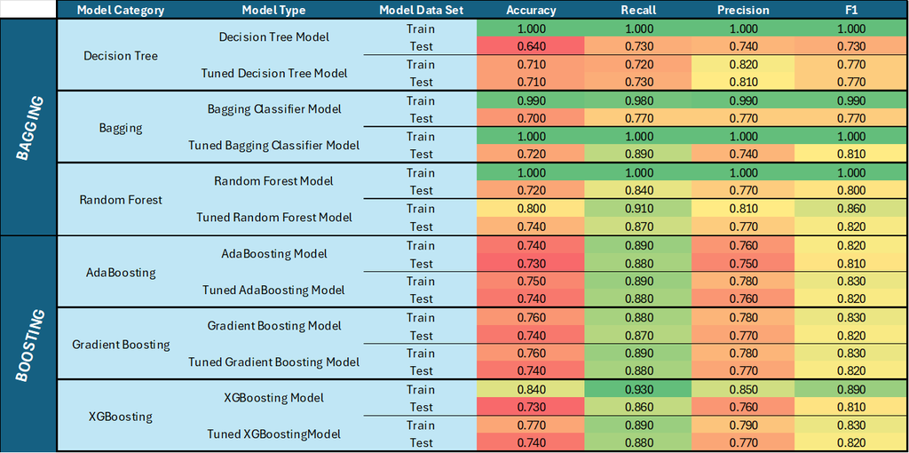

### Overall Observations on Model Performance:

**Decision Tree Models:**

- The basic Decision Tree model has perfect training performance (likely overfitting), but its test performance is lower, with a test F1 score of 0.734.
- The tuned Decision Tree shows a balanced performance between training and testing, though it’s still modest in both areas.

**Bagging Classifier Models:**

- The basic Bagging Classifier overfits slightly, but after tuning, it shows a significant improvement in test F1 score to 0.808, indicating a better generalization.

**Random Forest Models:**

- The Random Forest model performs well with a perfect training score, but its test performance is lower, with a test F1 score of 0.801.
- The tuned Random Forest model improves test F1 score to 0.816, suggesting that tuning has successfully reduced overfitting.

**AdaBoost Models:**

- The AdaBoost model, especially after tuning, performs well, showing a test F1 score around 0.819, making it a strong candidate.

**Gradient Boosting Models:**

- Both default and tuned Gradient Boosting models show strong performance with F1 scores around 0.820, indicating they are well-suited for the problem.

**XGBoost Models:**

- XGBoost models, both default and tuned, demonstrate strong performance. The tuned XGBoost model achieves a test F1 score of 0.820, making it one of the top-performing models.

**Best Model Selection:**

**Top Choice: Tuned XGBoost Model**

The tuned XGBoost model is the best choice overall, balancing high test accuracy, recall, precision, and F1 score. It demonstrates robustness and generalizes well to unseen data, which is crucial for the business context. Runner-Up: Tuned Gradient Boosting Model

The tuned Gradient Boosting model is a close second, with similar performance metrics. It might be a preferred option if computational efficiency or interpretability is a concern.

## Will tuning the hyperparameters improve the model performance?

**Yes, as seen in the overall model performance, tuning the hyperparameters improved in the majority of cases all the models.**

## Actionable Insights and Recommendations

### **Understand the Problem:**

- **Problem Analysis:** The problem at hand is the increasing volume of visa applications, which is making the manual review process labor-intensive and inefficient. In FY 2016, the OFLC processed nearly 776,000 applications for almost 1.7 million positions, a number that continues to grow annually. Given the rising demand, a machine learning-based solution is necessary to assist in shortlisting candidates with a higher likelihood of visa approval.
- **Objective:** Our goal is to develop a machine learning model that can accurately predict visa approvals, thereby streamlining the application review process. Additionally, we aim to recommend a suitable profile for applicants, highlighting key factors that significantly influence the visa certification decision.

### **Based on the Exploratory Data Analysis (EDA):**

- **Visa Certification by Continent:** The analysis indicates variability in visa certification rates across different continents. While Asia submits the most applications, Europe exhibits a higher certification rate. **Recommendation:** Prioritize recruitment in regions with higher certification rates, such as Europe, while optimizing processes for high-volume regions like Asia to increase approval rates.
- **Impact of Education Level on Visa Status:** Higher education levels, particularly Master's and Doctorate degrees, correlate with increased chances of visa certification. **Recommendation:** Focus on recruiting candidates with advanced degrees to improve the likelihood of visa approval, aligning with the preference for highly educated applicants.
- **Job Experience and Training:** Applicants with job experience have a higher visa approval rate, while the need for job training does not significantly impact the decision. **Recommendation:** Recruit candidates with relevant job experience and provide necessary training, as experience is a key determinant of visa success.
- **Region of Employment:** The certification rate varies across US employment regions, with some regions showing higher approval rates. **Recommendation:** Consider the region of employment during the hiring process, targeting regions with historically higher visa approval rates.
- **Wage Considerations:** Offering a competitive yearly salary is associated with higher visa certification rates. **Recommendation:** Ensure that foreign workers are offered salaries that align with or exceed the prevailing wage, particularly on a yearly basis, to increase the likelihood of approval.

### **Based on the Modeling Results:**

- **Model Performance:** The classification model effectively predicts visa certification outcomes based on key applicant and employer features, such as education, job experience, and wage. **Recommendation:** Integrate the model into the visa application review process to prioritize high-probability candidates, thereby enhancing efficiency and accuracy in decision-making.
- **Optimizing Recruitment:** The model's predictions can help identify high-potential candidates earlier in the recruitment process, reducing resources spent on processing applications likely to be denied. **Recommendation:** Utilize model insights to develop a data-driven recruitment strategy that focuses on candidates with the best chances of visa approval, aligning with business objectives to remain competitive in the talent market.

This comprehensive approach, grounded in data analysis and modeling, will enable OFLC and EasyVisa to optimize the visa approval process, making it more efficient and aligned with strategic business goals.

### Business Recommendations:

### 1. **Automate the Screening Process**

- **Leverage the Classification Model**: Integrate the machine learning model into the visa application process to automate the initial screening of candidates. This can significantly reduce the manual workload and focus human resources on the more complex cases that require detailed analysis.
- **Continuous Model Improvement**: Establish a process for continuous learning, where the model is retrained periodically with new data. This will help the model adapt to changes in visa approval patterns and improve accuracy over time.

### 2. **Enhance Data Collection**

- **Standardize Data Entry**: Ensure that all data related to visa applications is collected in a standardized format. This includes structured input for categorical data (e.g., education level, job experience) to improve the model's performance.
- **Expand Data Sources**: Incorporate additional data sources that could influence visa approvals, such as economic indicators, company financials, or employee testimonials. These additional features could provide deeper insights and improve model accuracy.

### 3. **Candidate Profile Optimization**

- **Profile Recommendations**: Use insights from the model to provide feedback to visa applicants. For instance, suggest potential improvements in their profiles (e.g., gaining relevant job experience, pursuing higher education) to increase their chances of visa approval.
- **Education and Training Programs**: Partner with educational institutions and training centers to offer courses that align with the skills and experiences that are highly valued in the visa approval process.

### 4. **Policy Advocacy**

- **Inform Policy Changes**: Share insights from the model with policymakers to help shape future visa regulations. For example, if certain education levels or job experiences are consistently leading to visa approvals, these could be prioritized in immigration policies.
- **Predictive Policy Impact**: Use the model to simulate how potential changes in visa policies might affect approval rates. This can help in making data-driven decisions at the policy level.

### 5. **Customer-Centric Services**

- **Applicant Support Services**: Develop services that assist visa applicants in preparing their profiles. This could include resume building, interview coaching, and document preparation services to ensure their applications meet the requirements highlighted by the model.
- **Real-Time Feedback**: Provide real-time feedback to applicants during the application process, helping them understand their approval probability based on current model predictions, and offering suggestions for improvement if necessary.

### 6. **Performance Monitoring and Reporting**

- **Develop Dashboards**: Create dashboards that allow stakeholders to monitor the performance of the machine learning model over time. This can include metrics like accuracy, recall, precision, and F1 scores across different applicant categories.
- **Regular Reports**: Provide regular reports to management and policymakers, summarizing trends in visa approvals and denials, and highlighting any shifts that could be of concern.

## Appendix

### Exploratory Data Analysis (EDA)

### Univariate Analysis

#### Categorical Features

```python
# Making a list of all categorical variables ()'object' or 'category')
cat_cols = df_eda.select_dtypes(include=["object", "category"]).columns
```

`continent`

```
Distribution of 'continent'
```

```
count     25480
unique        6
top        Asia
freq      16861
Name: continent, dtype: object
```

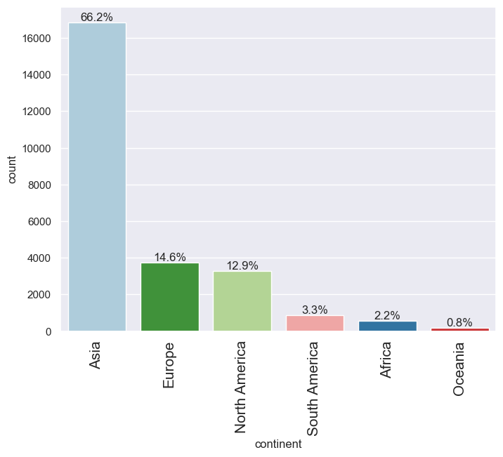

```python
print("Distribution of 'continent'")
display(df_eda["continent"].describe())
labeled_barplot(df_eda, "continent", perc=True)
print("-" * 100)
```

**Observations:**

- A significant majority of visa applicants come from Asia, accounting for 66.2% of the total applicants. This suggests that a large proportion of foreign workers seeking visas are from Asian countries.
- Other continents, such as Oceania (0.8%), South America (3.3%), and Africa (2.2%), have a much smaller representation among applicants, indicating that the majority of visa applications might be concentrated in regions with more established educational or industrial infrastructures.

`education_of_employee`

```
Distribution of 'education_of_employee'
```

```
count          25480
unique             4
top       Bachelor's
freq           10234
Name: education_of_employee, dtype: object
```

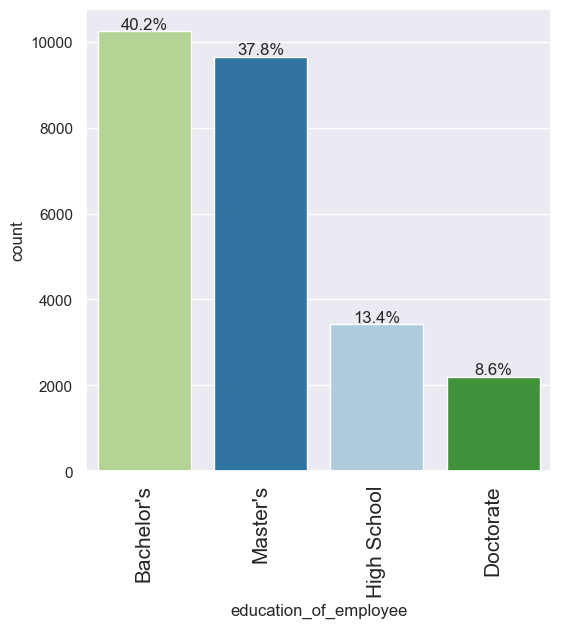

```python
print("Distribution of 'education_of_employee'")
display(df_eda["education_of_employee"].describe())
labeled_barplot(df_eda, "education_of_employee", perc=True)
print("-" * 100)
```

**Observations:**

`has_job_experience`

```
Distribution of 'has_job_experience'
```

```
count     25480
unique        2
top           Y
freq      14802
Name: has_job_experience, dtype: object
```

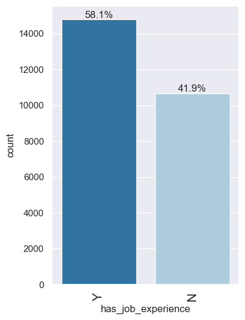

```python
print("Distribution of 'has_job_experience'")
display(df_eda["has_job_experience"].describe())
labeled_barplot(df_eda, "has_job_experience", perc=True)
print("-" * 100)
```

**Observations:**

- A large majority of applicants (58.1%) report having job experience, which could be an essential factor in securing a visa, as experienced professionals may be perceived as more valuable in specialized roles.

`requires_job_training`

```
Distribution of 'requires_job_training'
```

```
count     25480
unique        2
top           N
freq      22525
Name: requires_job_training, dtype: object
```

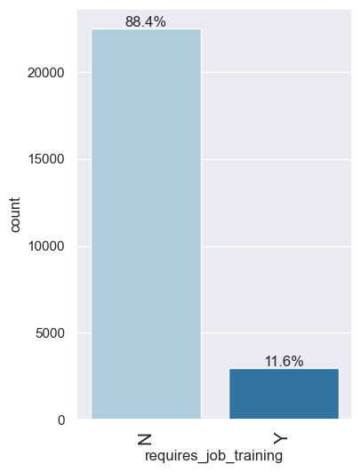

```python
print("Distribution of 'requires_job_training'")
display(df_eda["requires_job_training"].describe())
labeled_barplot(df_eda, "requires_job_training", perc=True)
print("-" * 100)
```

**Observations:**

- The vast majority of applicants (88.4%) do not require job training, which suggests that most applicants are already skilled or trained in their respective fields, making them immediately valuable to potential employers.

`region_of_employment`

```
Distribution of 'region_of_employment'
```

```
count         25480
unique            5
top       Northeast
freq           7195
Name: region_of_employment, dtype: object
```

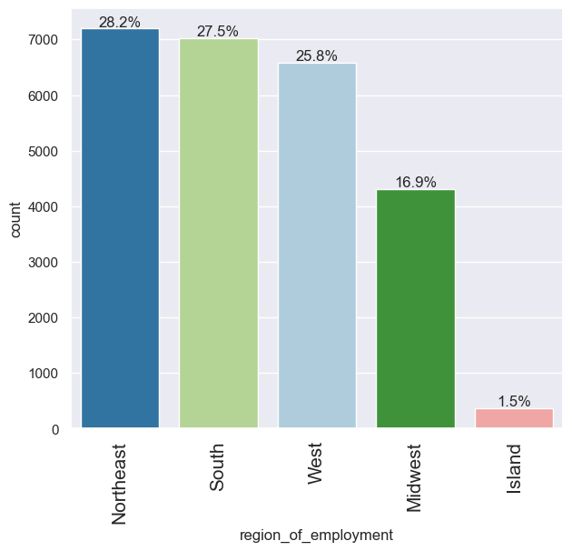

```python
print("Distribution of 'region_of_employment'")
display(df_eda["region_of_employment"].describe())
labeled_barplot(df_eda, "region_of_employment", perc=True)
print("-" * 100)
```

**Observations:**

- Northeast (28.2%), South (27.5%), and West (25.8%) are the most common employment regions, with a much smaller proportion in the Island region.

`unit_of_wage`

```
Distribution of 'unit_of_wage'
```

```
count     25480
unique        4
top        Year
freq      22962
Name: unit_of_wage, dtype: object
```

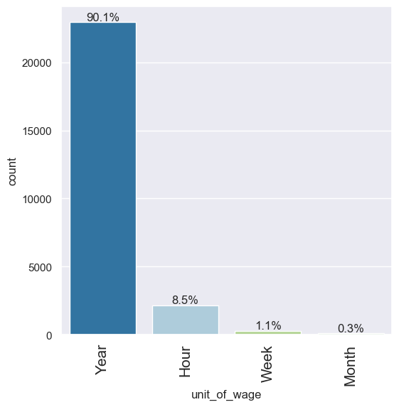

```python
print("Distribution of 'unit_of_wage'")
display(df_eda["unit_of_wage"].describe())
labeled_barplot(df_eda, "unit_of_wage", perc=True)
print("-" * 100)
```

**Observations:**

- Most applicants are compensated on a yearly basis (90.1%), with very few on hourly, weekly, or monthly rates.

`full_time_position`

```
Distribution of 'full_time_position'
```

```
count     25480
unique        2
top           Y
freq      22773
Name: full_time_position, dtype: object
```

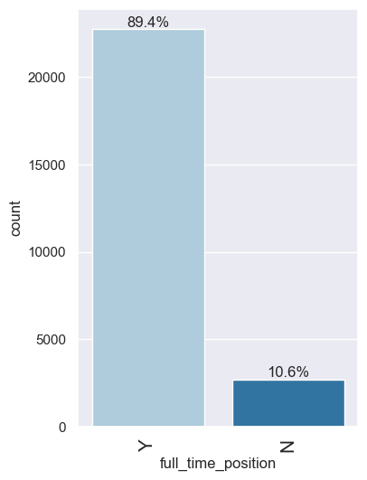

```python
print("Distribution of 'full_time_position'")
display(df_eda["full_time_position"].describe())
labeled_barplot(df_eda, "full_time_position", perc=True)
print("-" * 100)
```

**Observations:**

- 89.4% of the positions are full-time, showing that most visa applications are for full-time employment.

`case_status`

```
Distribution of 'case_status'
```

```
count         25480
unique            2
top       Certified
freq          17018
Name: case_status, dtype: object
```

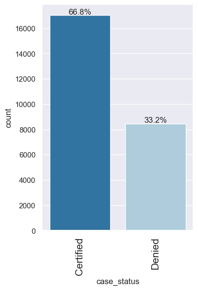

```python
print("Distribution of 'case_status'")
display(df_eda["case_status"].describe())
labeled_barplot(df_eda, "case_status", perc=True)
print("-" * 100)
```

**Observations:**

- 66.8% of the applications were Certified, while 33.2% were Denied.

#### Numerical Values

```python
# Making a list of all numerical variables ('int64', 'float64', 'complex')
num_cols = df_eda.select_dtypes(include=["int64", "float64", "complex"]).columns
```

`no_of_employees`

```
Distribution of 'no_of_employees'
```

```
count    25480.000
mean      5667.089
std      22877.917
min         11.000
25%       1022.000
50%       2109.000
75%       3504.000
max     602069.000
Name: no_of_employees, dtype: float64
```

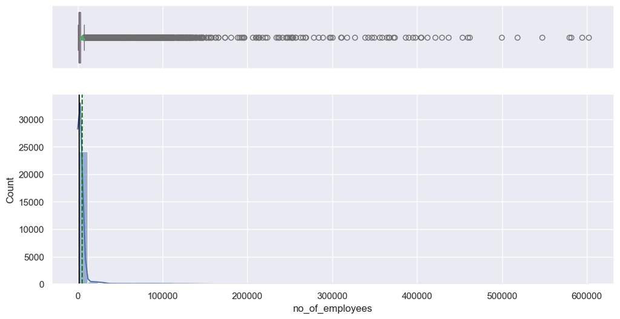

```python
print("Distribution of 'no_of_employees'")
display(df_eda["no_of_employees"].describe())
histogram_boxplot(df, "no_of_employees", bins=50, kde=True)
print("-" * 100)
```

**Observations:**

- There is a wide range of company sizes, from very small (11 employees) to very large (over 600,000 employees), but the majority of companies have fewer than 3,504 employees.

`yr_of_estab`

```
Distribution of 'yr_of_estab'
```

```
count   25480.000
mean     1979.410
std        42.367
min      1800.000
25%      1976.000
50%      1997.000
75%      2005.000
max      2016.000
Name: yr_of_estab, dtype: float64
```

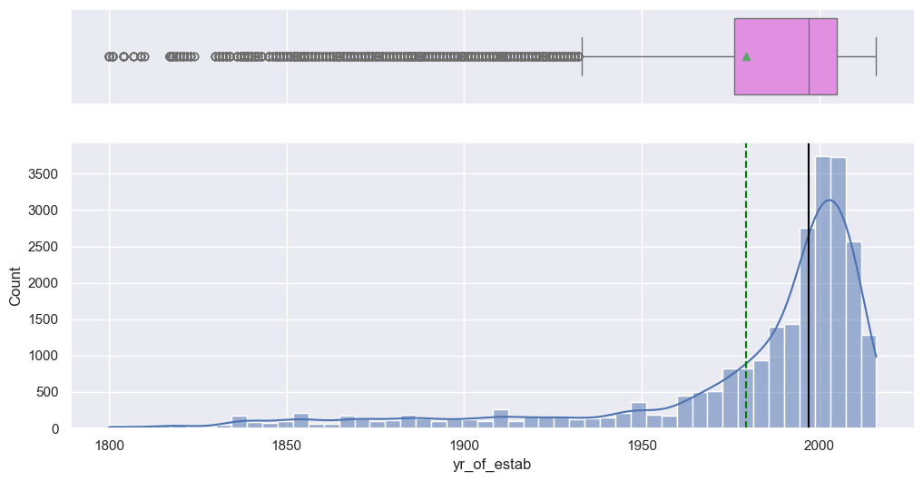

```python
print("Distribution of 'yr_of_estab'")
display(df_eda["yr_of_estab"].describe())
histogram_boxplot(df, "yr_of_estab", bins=50, kde=True)
print("-" * 100)
```

**Observations:**

- The companies range in age from very old (established in the 1800s) to relatively new, with a median establishment year of 1997. Most companies were established post-1976.

`prevailing_wage`

```
Distribution of 'prevailing_wage'
```

```
count    25480.000
mean     74455.815
std      52815.942
min          2.137
25%      34015.480
50%      70308.210
75%     107735.513
max     319210.270
Name: prevailing_wage, dtype: float64
```

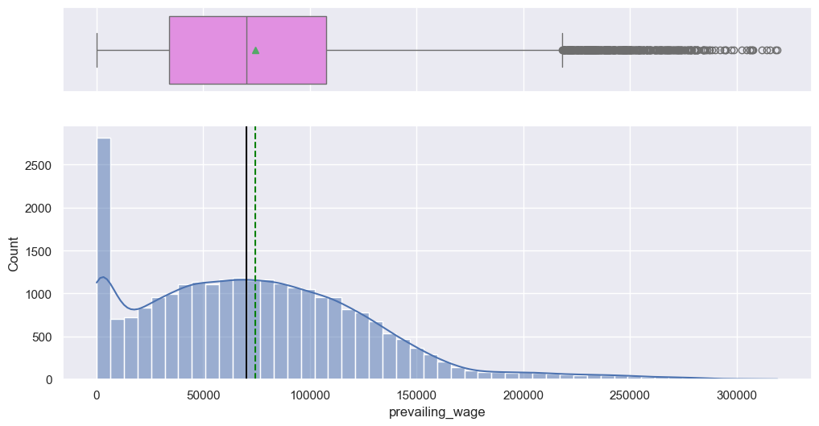

```python
print("Distribution of 'prevailing_wage'")
display(df_eda["prevailing_wage"].describe())
histogram_boxplot(df, "prevailing_wage", bins=50, kde=True)
print("-" * 100)
```

**Observations:**

- The prevailing wages range widely, with a median wage of $70,308. However, there are significant outliers, and the wage distribution is right-skewed with a concentration of lower wages.

### Multivariate Analysis

#### Heatmap Correlation Matrix

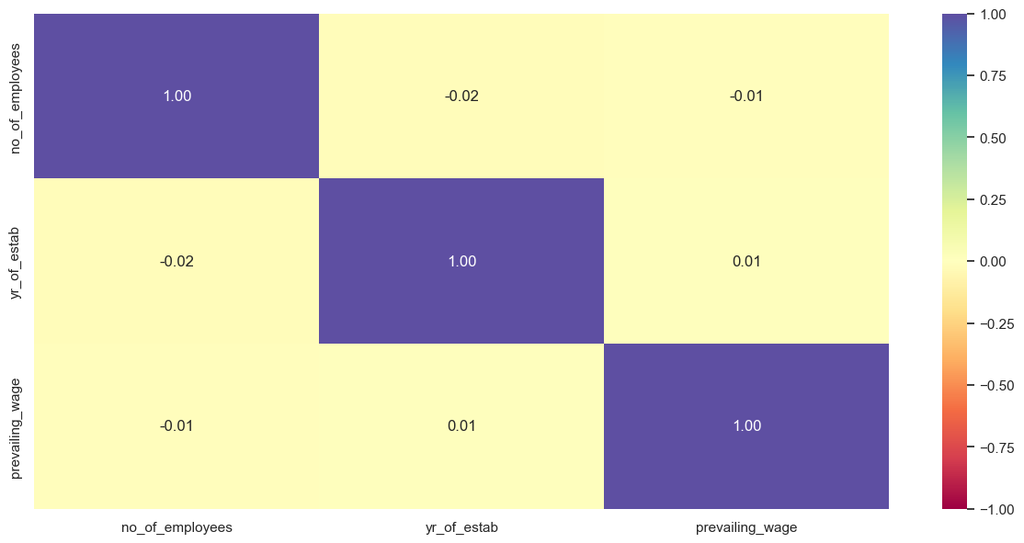

```python
# Visual representation
plt.figure(figsize=(15, 7))
sns.heatmap(
    df_eda[num_cols].corr(), annot=True, vmin=-1, vmax=1, fmt=".2f", cmap="Spectral"
)
plt.show()
```

**Observations:**

- The correlations between the numerical variables (no_of_employees, yr_of_estab, prevailing_wage) are very weak, indicating that these variables do not have strong linear relationships with each other.

#### Case Status vs. Numerical Features

`case_status` vs. `no_of_employees`

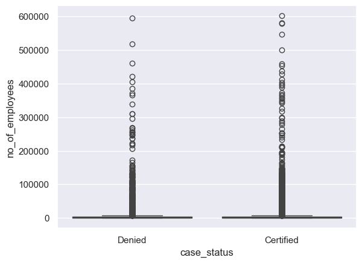

```python
sns.boxplot(x=df_eda["case_status"], y=df_eda["no_of_employees"], palette="PuBu")
```

**Observations:**

- There is no significant difference in the number of employees between certified and denied cases, indicating that the size of the company might not be a determining factor for visa certification.

`case_status` vs. `yr_of_estab`

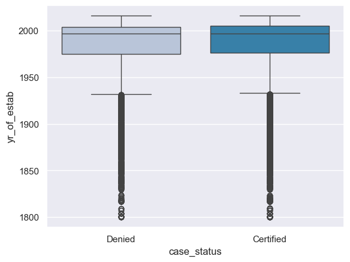

```python
sns.boxplot(x=df_eda["case_status"], y=df_eda["yr_of_estab"], palette="PuBu")
```

**Observations:**

- Companies established more recently have a slightly higher chance of visa certification, though the difference is not substantial.

`case_status` vs. `prevailing_wage`

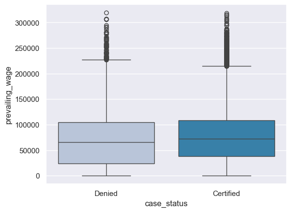

```python
sns.boxplot(x=df_eda["case_status"], y=df_eda["prevailing_wage"], palette="PuBu")
```

**Observations:**

- Certified cases tend to have slightly higher prevailing wages compared to denied cases, suggesting that higher wages might improve the chances of certification.

#### Case Status vs. Categorical Variables

```python
# Displaying a list of all categorical variables
print(cat_cols)
```

```
Index(['continent', 'education_of_employee', 'has_job_experience',
       'requires_job_training', 'region_of_employment', 'unit_of_wage',
       'full_time_position', 'case_status'],
      dtype='object')
```

`case_status` vs `continent`

```
case_status    Certified  Denied    All
continent
All                17018    8462  25480
Asia               11012    5849  16861
North America       2037    1255   3292
Europe              2957     775   3732
South America        493     359    852
Africa               397     154    551
Oceania              122      70    192
------------------------------------------------------------------------------------------------------------------------
```

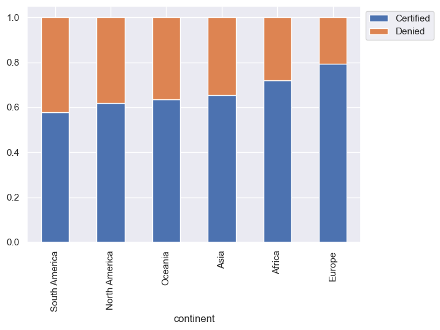

```python
stacked_barplot(df_eda, "continent", "case_status")
```

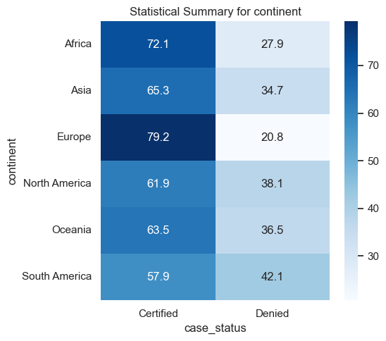

```python
# Define the dummy columns for 'continent'
continent_cols = [col for col in df_eda.columns if "continent" in col]

plt.figure(figsize=(10, 5 * len(continent_cols)))
for i, variable in enumerate(continent_cols):
    # Statistical summary
    summary = (
        df_eda.groupby(variable)["case_status"]
        .value_counts(normalize=True)
        .unstack()
        .fillna(0)
        * 100
    )
    plt.subplot(len(continent_cols), 2, 2 * i + 2)
    sns.heatmap(summary, annot=True, cmap="Blues", fmt=".1f")
    plt.title(f"Statistical Summary for {variable}")
    plt.tight_layout()

plt.show()
```

`case_status` vs `education_of_employee`

```
case_status            Certified  Denied    All
education_of_employee
All                        17018    8462  25480
Bachelor's                  6367    3867  10234
High School                 1164    2256   3420
Master's                    7575    2059   9634
Doctorate                   1912     280   2192
------------------------------------------------------------------------------------------------------------------------
```

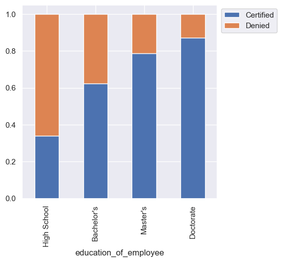

```python
stacked_barplot(df_eda, "education_of_employee", "case_status")
```

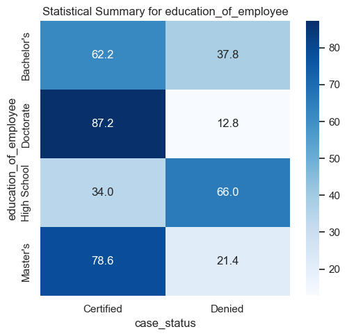

```python
# Define the dummy columns for 'education_of_employee'
eofe_cols = [col for col in df_eda.columns if "education_of_employee" in col]

plt.figure(figsize=(10, 5 * len(eofe_cols)))
for i, variable in enumerate(eofe_cols):
    # Statistical summary
    summary = (
        df_eda.groupby(variable)["case_status"]
        .value_counts(normalize=True)
        .unstack()
        .fillna(0)
        * 100
    )
    plt.subplot(len(eofe_cols), 2, 2 * i + 2)
    sns.heatmap(summary, annot=True, cmap="Blues", fmt=".1f")
    plt.title(f"Statistical Summary for {variable}")
    plt.tight_layout()

plt.show()
```

**Observations:**

- Higher education levels (Master's and Doctorate) are associated with higher certification rates, while High School graduates have the lowest certification rate.
- Bachelor's degree holders have a moderate certification rate.

`case_status` vs `has_job_experience`

```
case_status         Certified  Denied    All
has_job_experience
All                     17018    8462  25480
N                        5994    4684  10678
Y                       11024    3778  14802
------------------------------------------------------------------------------------------------------------------------
```

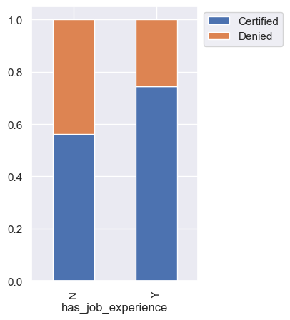

```python
stacked_barplot(df_eda, "has_job_experience", "case_status")
```

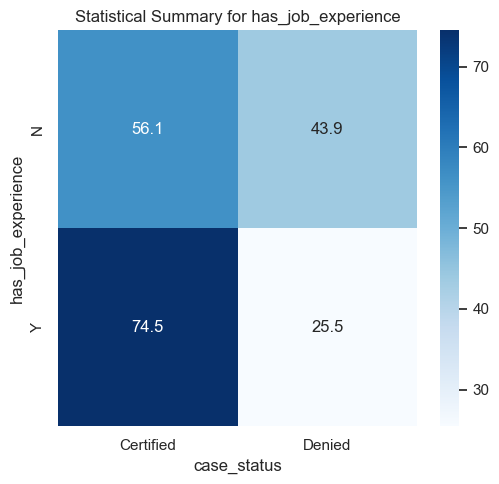

```python
# Define the dummy columns for 'has_job_experience'
job_exp_cols = [col for col in df_eda.columns if "has_job_experience" in col]

plt.figure(figsize=(10, 5 * len(job_exp_cols)))
for i, variable in enumerate(job_exp_cols):
    # Statistical summary
    summary = (
        df_eda.groupby(variable)["case_status"]
        .value_counts(normalize=True)
        .unstack()
        .fillna(0)
        * 100
    )
    plt.subplot(len(job_exp_cols), 2, 2 * i + 2)
    sns.heatmap(summary, annot=True, cmap="Blues", fmt=".1f")
    plt.title(f"Statistical Summary for {variable}")
    plt.tight_layout()

plt.show()
```

**Observations:**

- Employees with job experience have a higher certification rate compared to those without job experience.
- This suggests that experience plays a crucial role in the certification process.

`case_status` vs `requires_job_training`

```
case_status            Certified  Denied    All
requires_job_training
All                        17018    8462  25480
N                          15012    7513  22525
Y                           2006     949   2955
------------------------------------------------------------------------------------------------------------------------
```

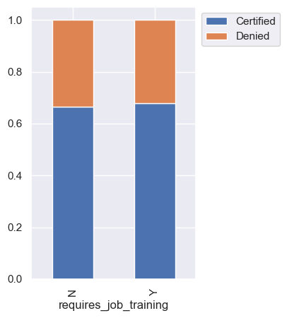

```python
stacked_barplot(df_eda, "requires_job_training", "case_status")
```

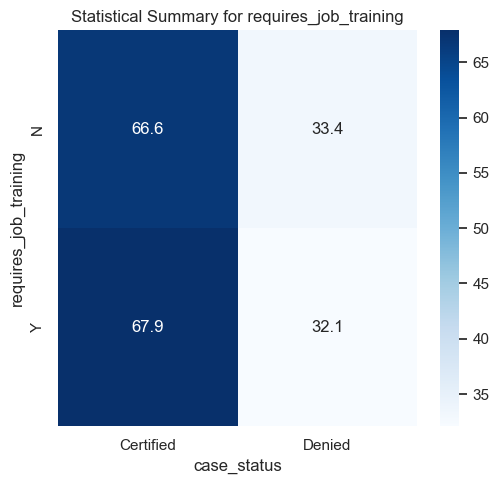

```python
# Define the dummy columns for 'requires_job_training'
req_job_trn_cols = [col for col in df_eda.columns if "requires_job_training" in col]

plt.figure(figsize=(10, 5 * len(req_job_trn_cols)))
for i, variable in enumerate(req_job_trn_cols):
    # Statistical summary
    summary = (
        df_eda.groupby(variable)["case_status"]
        .value_counts(normalize=True)
        .unstack()
        .fillna(0)
        * 100
    )
    plt.subplot(len(req_job_trn_cols), 2, 2 * i + 2)
    sns.heatmap(summary, annot=True, cmap="Blues", fmt=".1f")
    plt.title(f"Statistical Summary for {variable}")
    plt.tight_layout()

plt.show()
```

`case_status` vs `region_of_employment`

```
case_status           Certified  Denied    All
region_of_employment
All                       17018    8462  25480
Northeast                  4526    2669   7195
West                       4100    2486   6586
South                      4913    2104   7017
Midwest                    3253    1054   4307
Island                      226     149    375
------------------------------------------------------------------------------------------------------------------------
```

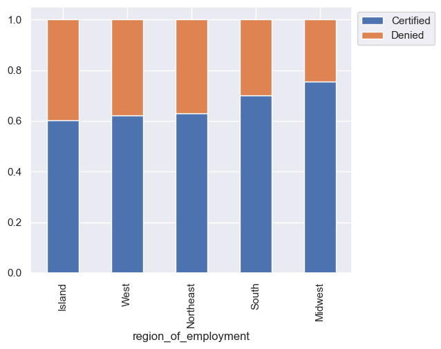

```python
stacked_barplot(df_eda, "region_of_employment", "case_status")
```

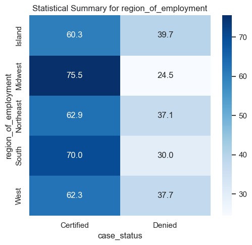

```python
# Define the dummy columns for 'region_of_employment'
reg_of_empl_cols = [col for col in df_eda.columns if "region_of_employment" in col]

plt.figure(figsize=(10, 5 * len(reg_of_empl_cols)))
for i, variable in enumerate(reg_of_empl_cols):
    # Statistical summary
    summary = (
        df_eda.groupby(variable)["case_status"]
        .value_counts(normalize=True)
        .unstack()
        .fillna(0)
        * 100
    )
    plt.subplot(len(reg_of_empl_cols), 2, 2 * i + 2)
    sns.heatmap(summary, annot=True, cmap="Blues", fmt=".1f")
    plt.title(f"Statistical Summary for {variable}")
    plt.tight_layout()

plt.show()
```

`case_status` vs `unit_of_wage`

```
case_status   Certified  Denied    All
unit_of_wage
All               17018    8462  25480
Year              16047    6915  22962
Hour                747    1410   2157
Week                169     103    272
Month                55      34     89
------------------------------------------------------------------------------------------------------------------------
```

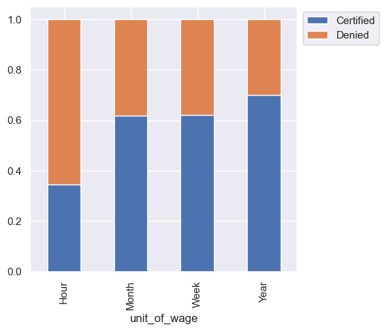

```python
stacked_barplot(df_eda, "unit_of_wage", "case_status")
```

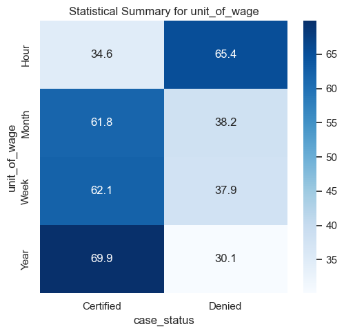

```python
# Define the dummy columns for 'unit_of_wage'
un_of_wg_cols = [col for col in df_eda.columns if "unit_of_wage" in col]

plt.figure(figsize=(10, 5 * len(un_of_wg_cols)))
for i, variable in enumerate(un_of_wg_cols):
    # Statistical summary
    summary = (
        df_eda.groupby(variable)["case_status"]
        .value_counts(normalize=True)
        .unstack()
        .fillna(0)
        * 100
    )
    plt.subplot(len(un_of_wg_cols), 2, 2 * i + 2)
    sns.heatmap(summary, annot=True, cmap="Blues", fmt=".1f")
    plt.title(f"Statistical Summary for {variable}")
    plt.tight_layout()

plt.show()
```

**Observations:**

- Employees paid on an hourly basis have the highest denial rate, while those paid on a yearly basis have the highest certification rate.
- This could be due to the stability associated with yearly wages.

`case_status` vs `full_time_position`

```
case_status         Certified  Denied    All
full_time_position
All                     17018    8462  25480
Y                       15163    7610  22773
N                        1855     852   2707
------------------------------------------------------------------------------------------------------------------------
```

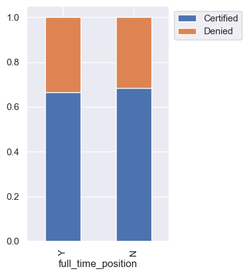

```python
stacked_barplot(df_eda, "full_time_position", "case_status")
```

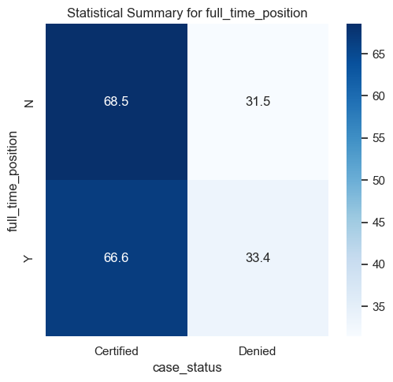

```python
# Define the dummy columns for 'full_time_position'
ft_pos_cols = [col for col in df_eda.columns if "full_time_position" in col]

plt.figure(figsize=(10, 5 * len(ft_pos_cols)))
for i, variable in enumerate(ft_pos_cols):
    # Statistical summary
    summary = (
        df_eda.groupby(variable)["case_status"]
        .value_counts(normalize=True)
        .unstack()
        .fillna(0)
        * 100
    )
    plt.subplot(len(ft_pos_cols), 2, 2 * i + 2)
    sns.heatmap(summary, annot=True, cmap="Blues", fmt=".1f")
    plt.title(f"Statistical Summary for {variable}")
    plt.tight_layout()

plt.show()
```

**Observations:**